# Offensive Scouting Pipeline: Cross-Team Summary

One R pipeline, 4 offenses, same 56-column GamePBP schema. Every report below was produced by the same call:

```
build_scouting_report(file,
team)
```

.

## At a glance

| Team | Data | Plays | Pass % | Neutral pass % | EPA/play | Success | 3rd-down conv | Sack % | Under center % | Run/pass predictability |
| --- | --- | --- | --- | --- | --- | --- | --- | --- | --- | --- |
| New York Giants | Real | 1075 | 58% | 48% | +0.01 | 46% | 41% | 8% | 23% | 58% -> 71% |
| Cleveland Browns | Real | 987 | 62% | 54% | -0.18 | 38% | 33% | 8% | 32% | 62% -> 76% |
| Houston Texans | Real | 1191 | 61% | 53% | -0.03 | 45% | 40% | 5% | 38% | 61% -> 76% |
| San Francisco 49ers | Real | 1158 | 59% | 52% | +0.07 | 53% | 50% | 4% | 45% | 59% -> 74% |

Predictability: share of plays a defense would call correctly (run vs pass) by always guessing the majority type, versus guessing from personnel + QB alignment + down + distance (leave-one-out).

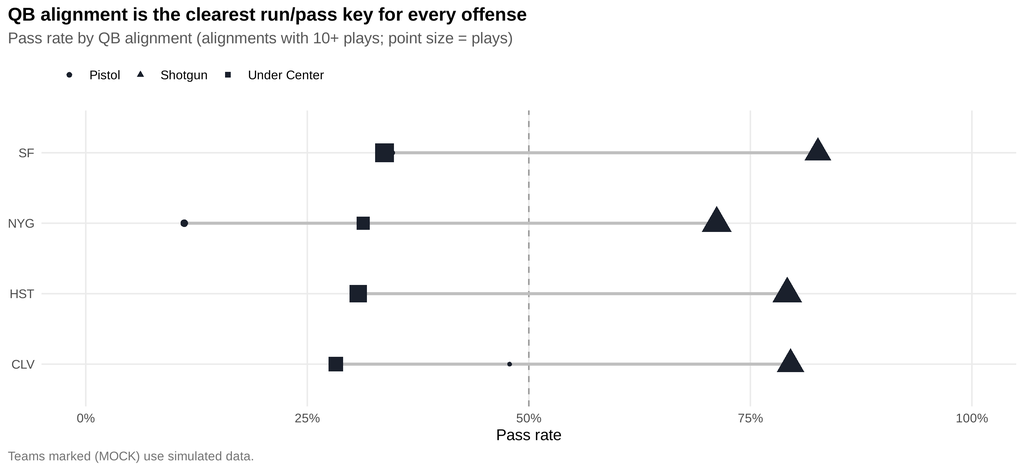

## Headline findings by team

### New York Giants (real data)

- **Tendency:** Passes on 58% of all plays and 48% of neutral early-down plays (1st/2nd down, outside 2-minute drills).
- **Tendency:** QB alignment is a strong run/pass key: under center they run 69% of the time (n=246); in shotgun they pass 71% (n=757).
- **Tendency:** Pistol is a real part of the menu: 72 plays, 11% pass.
- **Strength:** Most efficient run gap: Left Tackle, +0.13 EPA/carry, 4.4 YPC, 47% success (n=73).
- **Strength:** Primary target: W. Robinson (#17) (WR), 28% target share, 92 catches for 1014 yards, +0.15 EPA/target, 39 first downs.
- **Vulnerability:** Play action: 23% of dropbacks, -0.02 EPA/play vs +0.06 without (n=142 vs 482).
- **Vulnerability:** Pressure breaks the passing game: -0.46 EPA/dropback when pressured vs +0.26 clean. Pressured on 31% of dropbacks; sack rate 8%.

Full report: `NYG/NYG_scouting_report.html` (and .pdf)

### Cleveland Browns (real data)

- **Tendency:** Passes on 62% of all plays and 54% of neutral early-down plays (1st/2nd down, outside 2-minute drills).
- **Tendency:** QB alignment is a strong run/pass key: under center they run 72% of the time (n=319); in shotgun they pass 80% (n=645).
- **Tendency:** Pistol is a real part of the menu: 23 plays, 48% pass.
- **Strength:** Most efficient run gap: Right End, +0.02 EPA/carry, 4.5 YPC, 50% success (n=28).
- **Strength:** Primary target: J. Jeudy (#3) (WR), 20% target share, 48 catches for 580 yards, -0.31 EPA/target, 30 first downs.
- **Vulnerability:** Play action: 22% of dropbacks, -0.28 EPA/play vs -0.23 without (n=138 vs 476).
- **Vulnerability:** Deep shots (20+ air yards): 11% of targets, 28% complete, -0.22 EPA/target (n=53).

Full report: `CLV/CLV_scouting_report.html` (and .pdf)

### Houston Texans (real data)

- **Tendency:** Passes on 61% of all plays and 53% of neutral early-down plays (1st/2nd down, outside 2-minute drills).
- **Tendency:** QB alignment is a strong run/pass key: under center they run 69% of the time (n=452); in shotgun they pass 79% (n=739).
- **Tendency:** Base personnel is 11 (67% of snaps, 74% pass). 8 groupings reach 10+ plays.
- **Strength:** Most efficient run gap: Right Guard, +0.08 EPA/carry, 4.7 YPC, 53% success (n=89).
- **Strength:** Primary target: N. Collins (#12) (WR), 20% target share, 73 catches for 1134 yards, +0.29 EPA/target, 50 first downs.
- **Vulnerability:** Pressure breaks the passing game: -0.50 EPA/dropback when pressured vs +0.24 clean. Pressured on 28% of dropbacks; sack rate 5%.
- **Vulnerability:** Least efficient run gap: Right Tackle, -0.33 EPA/carry, stuffed (0 or fewer yards) on 25% (n=65).

Full report: `HST/HST_scouting_report.html` (and .pdf)

### San Francisco 49ers (real data)

- **Tendency:** Passes on 59% of all plays and 52% of neutral early-down plays (1st/2nd down, outside 2-minute drills).
- **Tendency:** QB alignment is a strong run/pass key: under center they run 66% of the time (n=522); in shotgun they pass 83% (n=610).
- **Tendency:** Pistol is a real part of the menu: 26 plays, 35% pass.
- **Strength:** Most efficient run gap: Middle, +0.12 EPA/carry, 4.0 YPC, 61% success (n=125).
- **Strength:** Primary target: C. McCaffrey (#23) (HB), 24% target share, 113 catches for 1009 yards, +0.33 EPA/target, 55 first downs.
- **Vulnerability:** Play action: 22% of dropbacks, +0.09 EPA/play vs +0.16 without (n=153 vs 536).
- **Vulnerability:** Pressure breaks the passing game: -0.48 EPA/dropback when pressured vs +0.35 clean. Pressured on 25% of dropbacks; sack rate 4%.

Full report: `SF/SF_scouting_report.html` (and .pdf)

## How the pipeline works

1. **Load and validate** any `.xlsx` (sheet `GamePBP`) or `.csv` in the PFF GamePBP layout. Headers are normalized, every column is read as text and converted on purpose, and missing optional columns are reported but don’t stop the run.
2. **Build the sample:** one offense, run/pass plays only, downs 1-4, excluding garbage time and QB kneels/spikes. Each filter step is counted in the report.
3. **Analyze** the six scouting questions from the prompt (personnel, down and distance, QB alignment, run concepts, third down and targets, player production) plus passing context and pre-snap tells.
4. **Write findings** with fixed rules (tendencies, strengths, vulnerabilities), each with its sample size, then render the HTML and PDF reports, the CSV/Excel tables and the PNG charts.
5. **Stress tested** on the mock files plus edge-case and regression checks (CSV input, messy headers, multi-team files, missing columns, one game, pass-only and run-only offenses, junk values, config switches).